# ParE3, Ostrov codes, landscape ruggedness

Hana Rozhonova

6/15/2022

```r
library(stringr)
library(ggplot2)
library(ggpubr)
library(reshape2)
library(gridExtra)
```

# Read the data

```r
results = read.delim("output/results")
colnames(results) = c("Id", "Block1", "Block2", "Block3", "Block4", "X", "Z", "B", "J", "Robustness", "NumPeaks", "MeanPeakHeight", "NoEpi", "MagEpi", "SsEpi", "RsEpi", "PropAccPaths")
# number of split codon blocks
results$numSplitBlocks = apply(results, 1, function(x) sum(x[c("X", "Z", "B", "J")]!="-"))
# number of stop codons
results$numStop = 3 - (results$Block2!="-") + 2*apply(results, 1, function(x) sum(x[c("Block1", "Block3", "Block4")]=="O"))
```

# Correlation of robustness with number of split codon blocks and number of stop codons

```r
cor.test(results$Robustness, results$numSplitBlocks)
```

```
##
##  Pearson's product-moment correlation
##
## data:  results$Robustness and results$numSplitBlocks
## t = -161.96, df = 194478, p-value < 2.2e-16
## alternative hypothesis: true correlation is not equal to 0
## 95 percent confidence interval:
##  -0.3486618 -0.3408295
## sample estimates:
##        cor
## -0.3447517
```

```r
cor.test(results$Robustness, results$numStop)
```

```
##
##  Pearson's product-moment correlation
##
## data:  results$Robustness and results$numStop
## t = -71.253, df = 194478, p-value < 2.2e-16
## alternative hypothesis: true correlation is not equal to 0
## 95 percent confidence interval:
##  -0.1638331 -0.1551705
## sample estimates:
##        cor
## -0.1595049
```

# Peaks

#### Histogram of the number of peaks

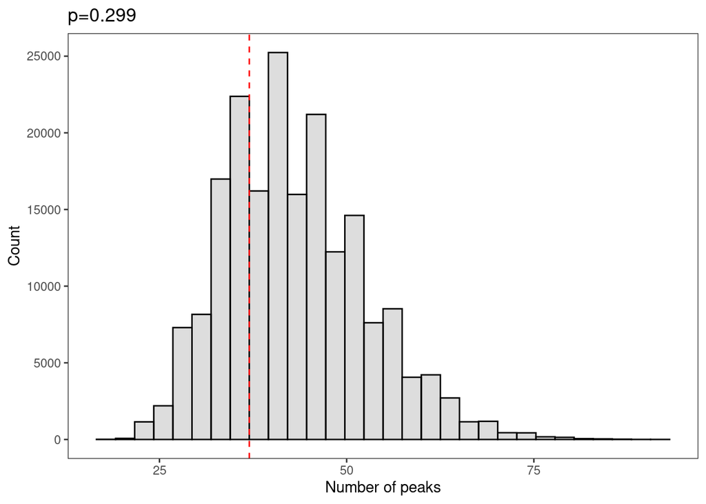

```r
peaks_standard = results$NumPeaks[results$Id=="standard"]
p = sum(results$NumPeaks<=peaks_standard)/nrow(results)
ggplot(results, aes(x=NumPeaks)) +
  geom_histogram(alpha=0.2, color="black") +
  theme_test() +
  geom_vline(xintercept=peaks_standard, linetype="dashed", color="red") +
  labs(x="Number of peaks", y="Count", title=paste0("p=", signif(p, digits=3)))
```

#### Correlation of number of peaks with code robustness

```r
(corTest = cor.test(results$NumPeaks, results$Robustness))
```

```
##
##  Pearson's product-moment correlation
##
## data:  results$NumPeaks and results$Robustness
## t = -138.9, df = 194478, p-value < 2.2e-16
## alternative hypothesis: true correlation is not equal to 0
## 95 percent confidence interval:
##  -0.3044503 -0.2963637
## sample estimates:
##        cor
## -0.3004124
```

Density plot:

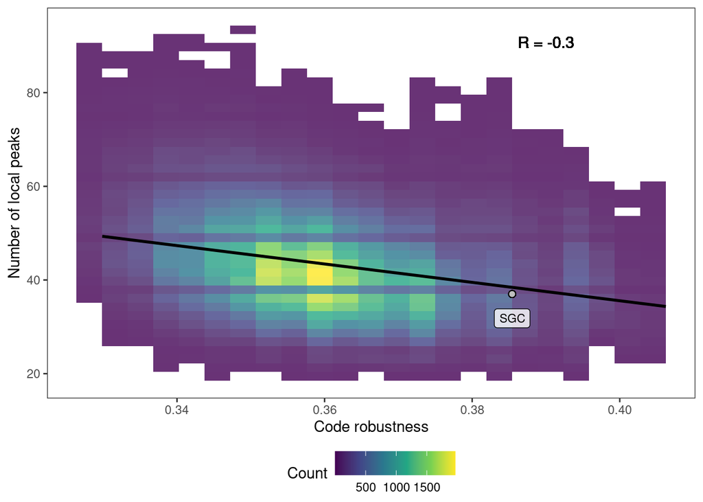

```r
rob_standard = results$Robustness[results$Id=="standard"]
(p_peaks_rob = ggplot(results, aes(x=Robustness, y=NumPeaks)) +
  geom_bin2d(bins=c(22,40), alpha=0.8) +
  scale_fill_continuous(type = "viridis", name="Count") +
  theme_test() +
  theme(legend.position="bottom") +
  geom_point(x=rob_standard, y=peaks_standard, fill="gray", pch=21, size=2) +
  labs(x="Code robustness", y="Number of local peaks") +
  geom_smooth(color="black", method="lm") +
  geom_text(label=paste0("R = ", signif(corTest$estimate, digits=3)), x=0.39, y=max(results$NumPeaks)-0.03*(max(results$NumPeaks)-min(results$NumPeaks)), size=4) +
  annotate(geom = "label", x=rob_standard, y=peaks_standard-0.07*(max(results$NumPeaks)-min(results$NumPeaks)), label="SGC", alpha=0.8, size=3))
```

#### Number of split codon blocks

Correlation:

```r
(corTest = cor.test(results$numSplitBlocks, results$NumPeaks))
```

```
##
##  Pearson's product-moment correlation
##
## data:  results$numSplitBlocks and results$NumPeaks
## t = 384.29, df = 194478, p-value < 2.2e-16
## alternative hypothesis: true correlation is not equal to 0
## 95 percent confidence interval:
##  0.6544380 0.6594903
## sample estimates:
##       cor
## 0.6569715
```

Boxplot - number of peaks:

[output not shown]

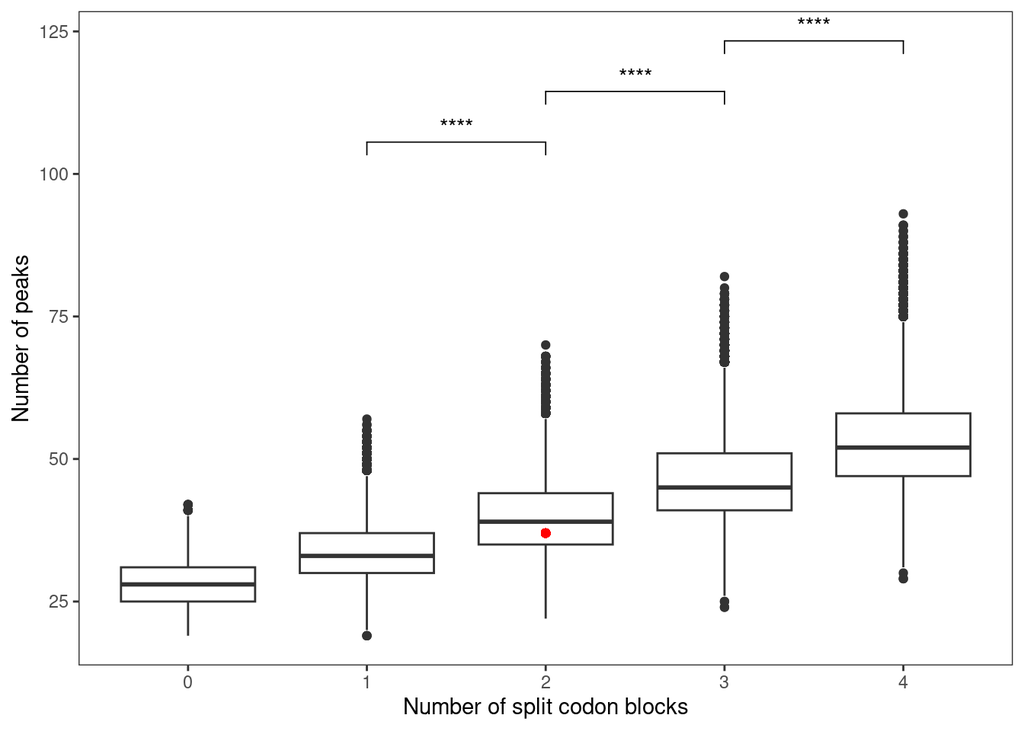

```r
comparisons_numSplit = list(c(0,1), c(1,2), c(2,3), c(3,4))
ggplot(results, aes(x=numSplitBlocks, y=NumPeaks, group=numSplitBlocks)) +
  geom_boxplot() +
  geom_point(x=2, y=peaks_standard, color="red") +
  theme_test() +
  labs(x="Number of split codon blocks", y="Number of peaks") +
  stat_compare_means(comparisons = comparisons_numSplit, label = "p.signif")
```

Hold robustness constant, is there still correlation between number of split codon blocks and number of peaks?

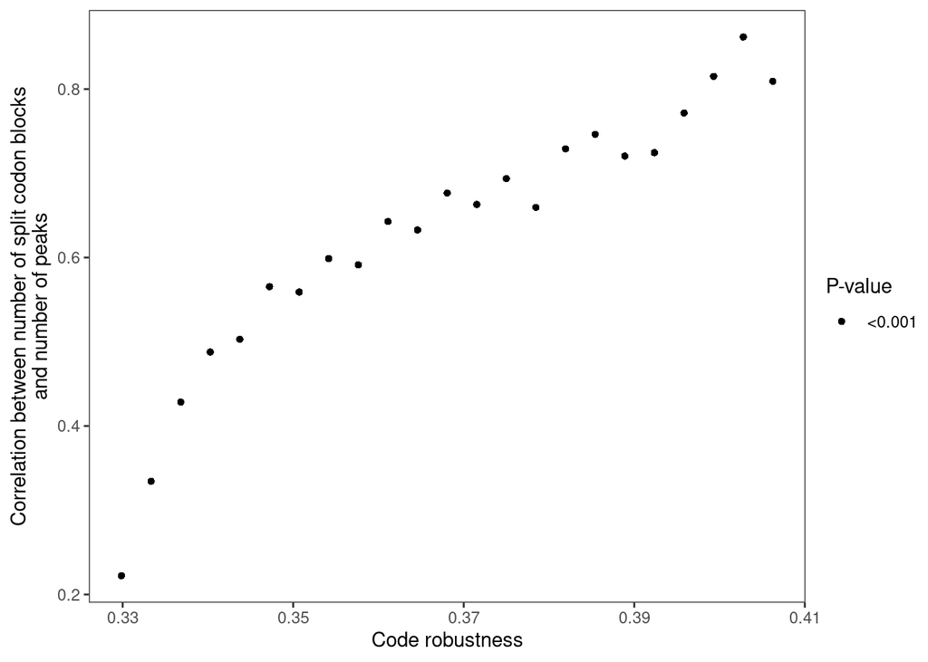

```r
corrs = c()
pvals = c()
robs = unique(results$Robustness)
for (rob in robs) {
  tmp = results[results$Robustness==rob,]
  test = cor.test(tmp$numSplitBlocks, tmp$NumPeaks)
  corrs = c(corrs, test$estimate)
  pvals = c(pvals, test$p.value)
}
data = data.frame(Robustness = robs,
                  Correlation = corrs,
                  Pvalue = pvals)
data$pval_cat = ifelse(data$Pvalue>=0.05, ">=0.05",
                       ifelse(data$Pvalue>=0.01, ">=0.01",
                              ifelse(data$Pvalue>=0.001, ">=0.001", "<0.001")))

ggplot(data, aes(x=Robustness, y=Correlation, shape=pval_cat)) +
  geom_point() + theme_test() +
  labs(y="Correlation between number of split codon blocks\nand number of peaks", x="Code robustness") +
  scale_shape_discrete(name="P-value")
```

#### Number of stop codons

```r
cor.test(results$numStop, results$NumPeaks)
```

```
##
##  Pearson's product-moment correlation
##
## data:  results$numStop and results$NumPeaks
## t = -16.88, df = 194478, p-value < 2.2e-16
## alternative hypothesis: true correlation is not equal to 0
## 95 percent confidence interval:
##  -0.04268612 -0.03381036
## sample estimates:
##         cor
## -0.03824899
```

```r
for (numSplit in unique(results$numSplitBlocks)) {
  print(numSplit)
  tmp = results[results$numSplitBlocks==numSplit,]
  print(cor.test(tmp$numStop, tmp$NumPeaks))
}
```

```
## [1] 3
##
##  Pearson's product-moment correlation
##
## data:  tmp$numStop and tmp$NumPeaks
## t = 46.68, df = 70868, p-value < 2.2e-16
## alternative hypothesis: true correlation is not equal to 0
## 95 percent confidence interval:
##  0.1655639 0.1798495
## sample estimates:
##       cor
## 0.1727158
##
## [1] 2
##
##  Pearson's product-moment correlation
##
## data:  tmp$numStop and tmp$NumPeaks
## t = 63.999, df = 64093, p-value < 2.2e-16
## alternative hypothesis: true correlation is not equal to 0
## 95 percent confidence interval:
##  0.2377933 0.2523468
## sample estimates:
##       cor
## 0.2450839
##
## [1] 1
##
##  Pearson's product-moment correlation
##
## data:  tmp$numStop and tmp$NumPeaks
## t = 51.37, df = 25965, p-value < 2.2e-16
## alternative hypothesis: true correlation is not equal to 0
## 95 percent confidence interval:
##  0.2926524 0.3147345
## sample estimates:
##       cor
## 0.3037342
##
## [1] 4
```

```
##
##  Pearson's product-moment correlation
##
## data:  tmp$numStop and tmp$NumPeaks
## t = NA, df = 29581, p-value = NA
## alternative hypothesis: true correlation is not equal to 0
## 95 percent confidence interval:
##  NA NA
## sample estimates:
## cor
##  NA
##
## [1] 0
##
##  Pearson's product-moment correlation
##
## data:  tmp$numStop and tmp$NumPeaks
## t = 24.232, df = 3963, p-value < 2.2e-16
## alternative hypothesis: true correlation is not equal to 0
## 95 percent confidence interval:
##  0.3318187 0.3860472
## sample estimates:
##       cor
## 0.3592361
```

Boxplot - number of peaks (for given number of split codon blocks):

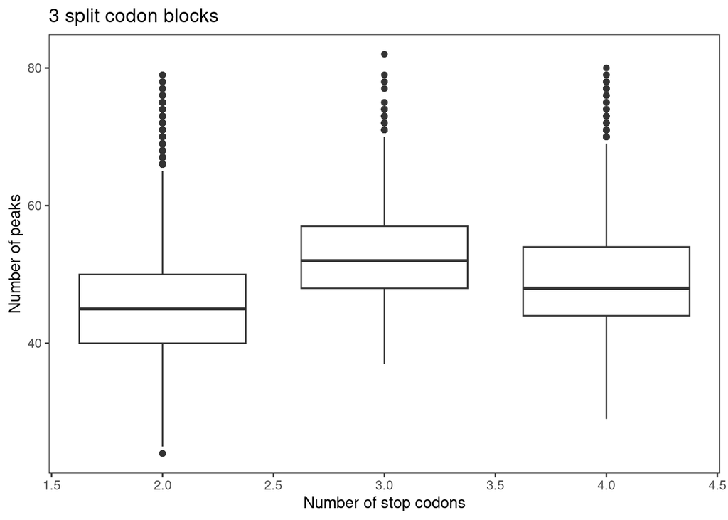

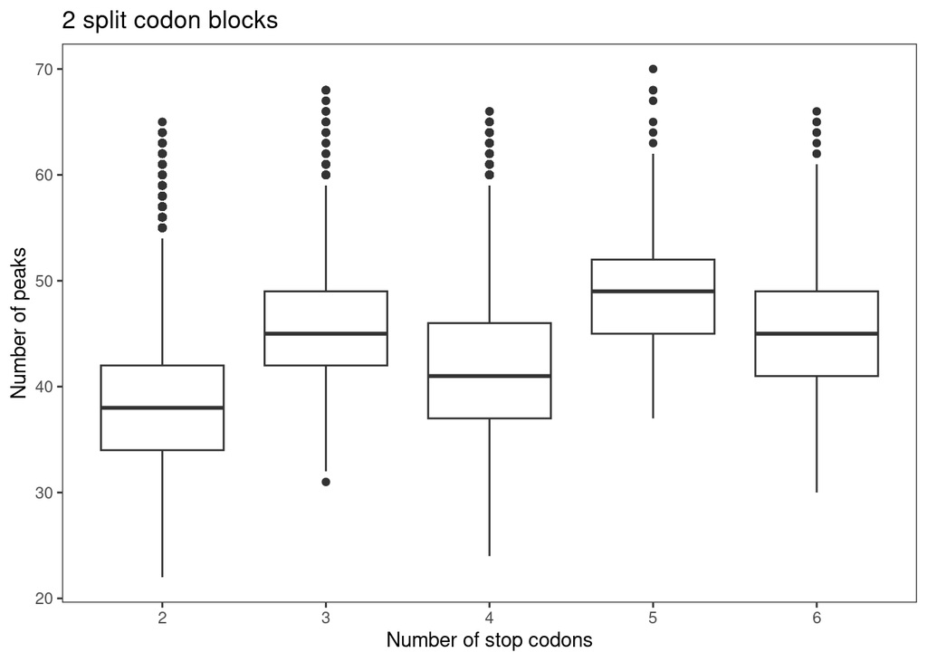

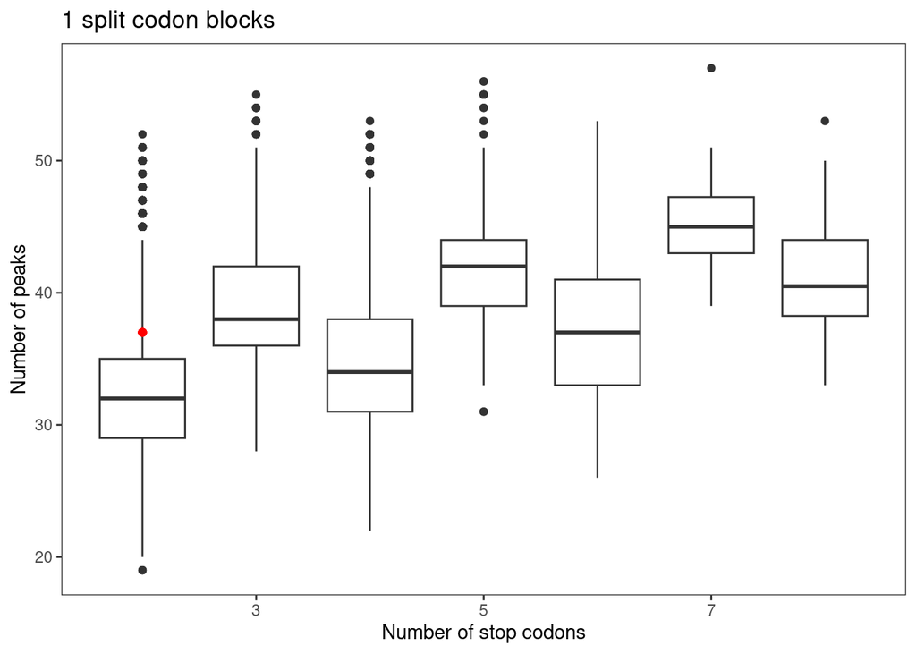

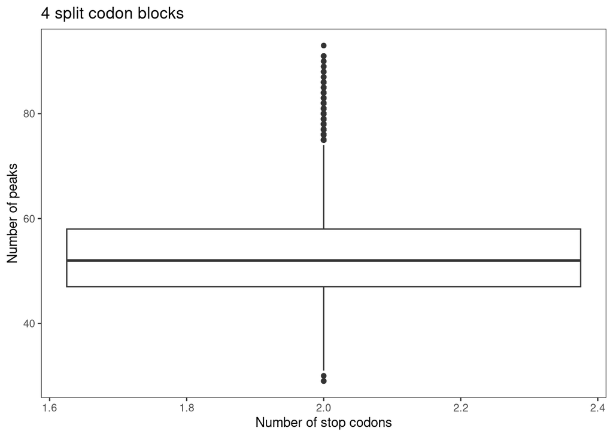

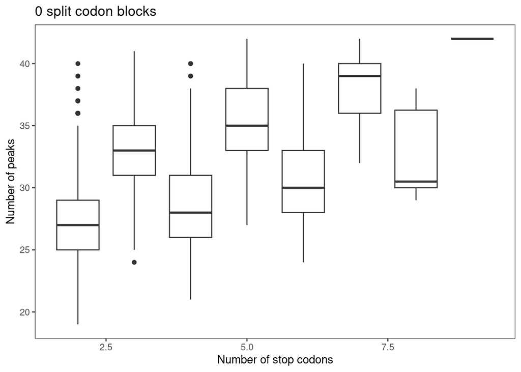

```r
for (numSplit in unique(results$numSplitBlocks)) {
  tmp = results[results$numSplitBlocks==numSplit,]
  p= ggplot(tmp, aes(x=numStop, y=NumPeaks, group=numStop)) +
    geom_boxplot() +
    theme_test() +
    labs(x="Number of stop codons", y="Number of peaks", title=paste(numSplit, "split codon blocks")) +
    stat_compare_means()
  if(numSplit==1) {
    p = p+geom_point(x=2, y=peaks_standard, color="red")
  }
  print(p)
}
```

Hold robustness constant, is there still correlation between number of stop codons and number of peaks?

```r
corrs = c()
pvals = c()
numSplit = c()
robs = unique(results$Robustness)
robs2 = c()
for (rob in robs) {
  tmp = results[results$Robustness==rob,]
  numsplits = unique(tmp$numSplitBlocks)
  for (ns in numsplits) {
    tmp_tmp = tmp[tmp$numSplitBlocks==ns,]
    test = cor.test(tmp_tmp$numStop, tmp_tmp$NumPeaks)
    corrs = c(corrs, test$estimate)
    pvals = c(pvals, test$p.value)
    numSplit = c(numSplit, ns)
    robs2 = c(robs2, rob)
  }
}
```

[output not shown]

[output cut: 18 more lines]

[output not shown]

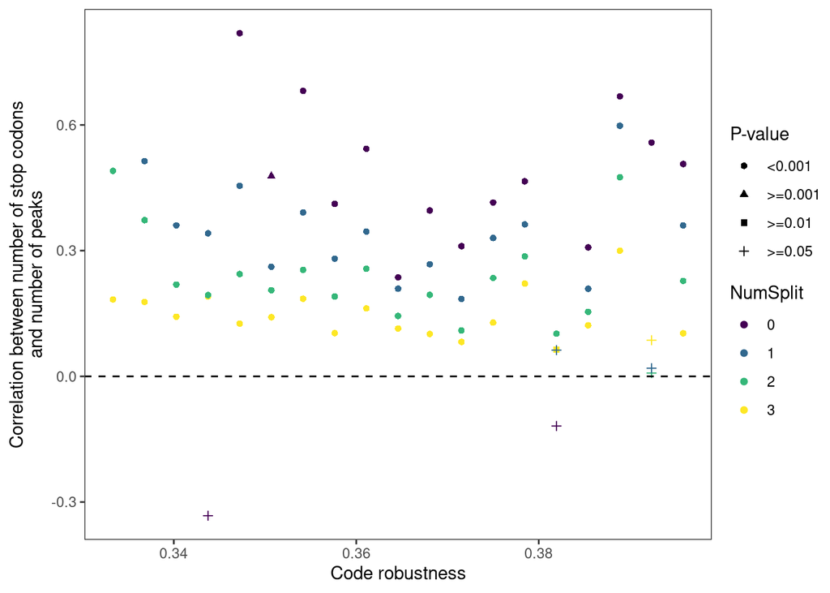

```r
data = data.frame(Robustness = robs2,
                  Correlation = corrs,
                  Pvalue = pvals,
                  NumSplit = numSplit)

data$pval_cat = ifelse(data$Pvalue>=0.05, ">=0.05",
                       ifelse(data$Pvalue>=0.01, ">=0.01",
                              ifelse(data$Pvalue>=0.001, ">=0.001", "<0.001")))

data$NumSplit = as.factor(data$NumSplit)
data = data[!is.na(data$Correlation),]
ggplot(data, aes(x=Robustness, y=Correlation, color=NumSplit, shape=pval_cat)) +
  geom_point() + theme_test() +
  labs(y="Correlation between number of stop codons\nand number of peaks", x="Code robustness", main="ParE3") +
  scale_color_viridis_d() + geom_hline(yintercept=0, linetype="dashed") +
  scale_shape_discrete(name="P-value")
```

# Accessibility of the global peak

#### Histogram

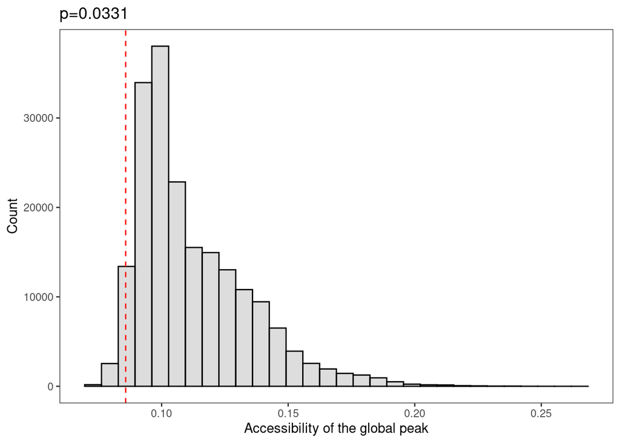

```r
acc_standard = results$PropAccPaths[results$Id=="standard"]
p = sum(results$PropAccPaths<=acc_standard)/nrow(results)
ggplot(results, aes(x=PropAccPaths)) +
  geom_histogram(alpha=0.2, color="black") +
  theme_test() +
  geom_vline(xintercept=acc_standard, linetype="dashed", color="red") +
  labs(x="Accessibility of the global peak", y="Count", title=paste0("p=", signif(p, digits=3)))
```

#### Correlation of global peak accessibility with code robustness

```r
(corTest = cor.test(results$PropAccPaths, results$Robustness))
```

```
##
##  Pearson's product-moment correlation
##
## data:  results$PropAccPaths and results$Robustness
## t = -104.33, df = 194478, p-value < 2.2e-16
## alternative hypothesis: true correlation is not equal to 0
## 95 percent confidence interval:
##  -0.2344310 -0.2260133
## sample estimates:
##        cor
## -0.2302265
```

The plot:

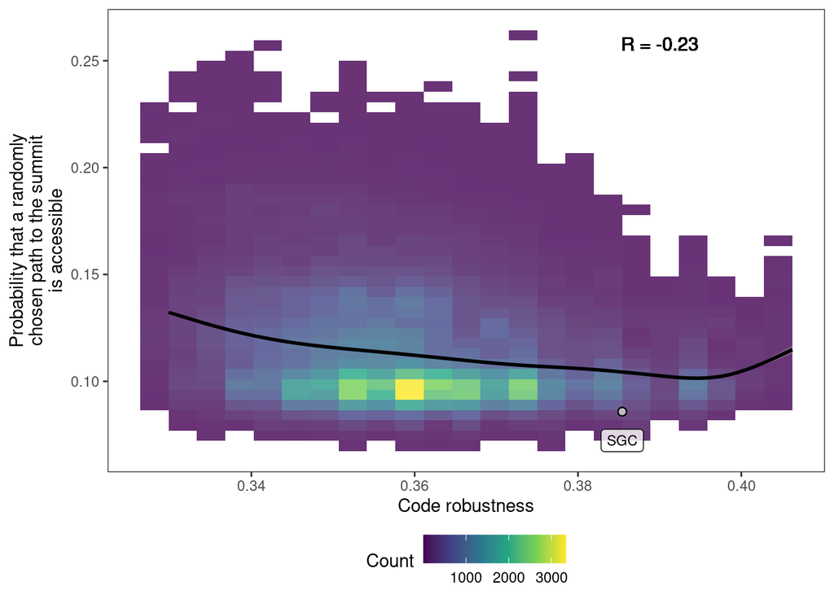

```r
(p_paths_rob = ggplot(results, aes(x=Robustness, y=PropAccPaths)) +
  geom_bin2d(bins=c(22,40), alpha=0.8) +
  scale_fill_continuous(type = "viridis", name="Count") +
  theme_test() +
   theme(legend.position="bottom") +
  geom_point(x=rob_standard, y=acc_standard, fill="gray", pch=21, size=2) +
  labs(x="Code robustness", y="Probability that a randomly\nchosen path to the summit\nis accessible") +
  geom_smooth(color="black") +
  geom_text(label=paste0("R = ", signif(corTest$estimate, digits=3)), x=0.39, y=max(results$PropAccPaths)-0.03*(max(results$PropAccPaths)-min(results$PropAccPaths)), size=4) +
  annotate(geom = "label", x=rob_standard, y=acc_standard-0.07*(max(results$PropAccPaths)-min(results$PropAccPaths)), label="SGC", alpha=0.8, size=3))
```

Restrict to only those codes where the size of the summit is the same as in the SGC and the summit is not split:

```r
results$nCodons_D = 2
results$nCodons_W = 1+2*(results$Block1=="W") + 1*(results$Block2=="W") + 2*(results$Block3=="W") + 2*(results$Block4=="W")
results$nCodons_E = 2+2*(results$Block1=="E") + 1*(results$Block2=="E")
results$SummitSize = results$nCodons_E * results$nCodons_D * results$nCodons_W

results$splitE = rowSums(results[,6:9]=="E" )
results$splitD = rowSums(results[,6:9]=="D")
results$splitW = rowSums(results[,6:9]=="W")

tmp_results = results[results$SummitSize==results$SummitSize[results$Id=="standard"] &
                results$splitE==0 & results$splitD==0 & results$splitW==0,]

cor.test(tmp_results$PropAccPaths, tmp_results$Robustness)
```

```
##
##  Pearson's product-moment correlation
##
## data:  tmp_results$PropAccPaths and tmp_results$Robustness
## t = 12.488, df = 104974, p-value < 2.2e-16
## alternative hypothesis: true correlation is not equal to 0
## 95 percent confidence interval:
##  0.03247173 0.04455235
## sample estimates:
##        cor
## 0.03851345
```

#### Number of split codon blocks

Correlation:

```r
(corTest = cor.test(tmp_results$numSplitBlocks, tmp_results$PropAccPaths))
```

```
##
##  Pearson's product-moment correlation
##
## data:  tmp_results$numSplitBlocks and tmp_results$PropAccPaths
## t = -85.916, df = 104974, p-value < 2.2e-16
## alternative hypothesis: true correlation is not equal to 0
## 95 percent confidence interval:
##  -0.2619605 -0.2506567
## sample estimates:
##        cor
## -0.2563174
```

Hold robustness constant, is there still correlation between number of split codon blocks and mutational accessibility?

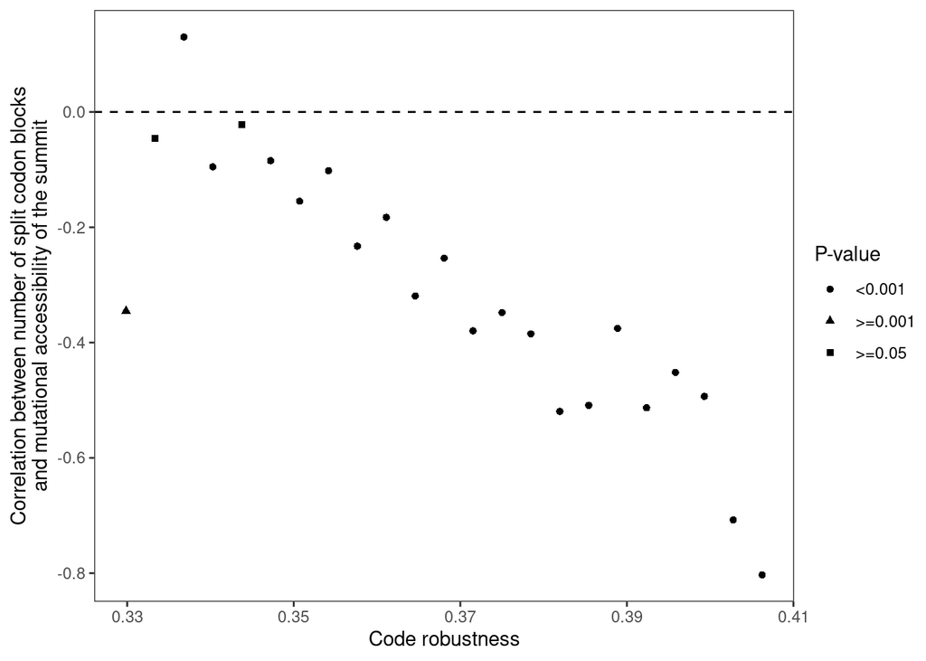

```r
corrs = c()
pvals = c()
robs = unique(tmp_results$Robustness)
for (rob in robs) {
  tmp = tmp_results[tmp_results$Robustness==rob,]
  test = cor.test(tmp$numSplitBlocks, tmp$PropAccPaths)
  corrs = c(corrs, test$estimate)
  pvals = c(pvals, test$p.value)
}
data = data.frame(Robustness = robs,
                  Correlation = corrs,
                  Pvalue = pvals)
data$pval_cat = ifelse(data$Pvalue>=0.05, ">=0.05",
                       ifelse(data$Pvalue>=0.01, ">=0.01",
                              ifelse(data$Pvalue>=0.001, ">=0.001", "<0.001")))

ggplot(data, aes(x=Robustness, y=Correlation, shape=pval_cat)) +
  geom_point() + theme_test() +
  labs(y="Correlation between number of split codon blocks\nand mutational accessibility of the summit", x="Code robustness") +
  scale_shape_discrete(name="P-value") +
  geom_hline(yintercept=0, linetype="dashed")
```

#### Number of stop codons

```r
cor.test(tmp_results$numStop, tmp_results$PropAccPaths)
```

```
##
##  Pearson's product-moment correlation
##
## data:  tmp_results$numStop and tmp_results$PropAccPaths
## t = -73.885, df = 104974, p-value < 2.2e-16
## alternative hypothesis: true correlation is not equal to 0
## 95 percent confidence interval:
##  -0.2280766 -0.2165760
## sample estimates:
##       cor
## -0.222334
```

```r
for (numSplit in unique(tmp_results$numSplitBlocks)) {
  print(numSplit)
  tmp = tmp_results[tmp_results$numSplitBlocks==numSplit,]
  print(cor.test(tmp$numStop, tmp$PropAccPaths))
}
```

```
## [1] 3
##
##  Pearson's product-moment correlation
##
## data:  tmp$numStop and tmp$PropAccPaths
## t = -50.302, df = 37815, p-value < 2.2e-16
## alternative hypothesis: true correlation is not equal to 0
## 95 percent confidence interval:
##  -0.2598552 -0.2409617
## sample estimates:
##        cor
## -0.2504323
##
## [1] 4
```

```
##
##  Pearson's product-moment correlation
##
## data:  tmp$numStop and tmp$PropAccPaths
## t = NA, df = 15118, p-value = NA
## alternative hypothesis: true correlation is not equal to 0
## 95 percent confidence interval:
##  NA NA
## sample estimates:
## cor
##  NA
##
## [1] 2
##
##  Pearson's product-moment correlation
##
## data:  tmp$numStop and tmp$PropAccPaths
## t = -68.092, df = 35183, p-value < 2.2e-16
## alternative hypothesis: true correlation is not equal to 0
## 95 percent confidence interval:
##  -0.3504312 -0.3319664
## sample estimates:
##        cor
## -0.3412317
##
## [1] 1
##
##  Pearson's product-moment correlation
##
## data:  tmp$numStop and tmp$PropAccPaths
## t = -53.738, df = 14573, p-value < 2.2e-16
## alternative hypothesis: true correlation is not equal to 0
## 95 percent confidence interval:
##  -0.4201398 -0.3930389
## sample estimates:
##        cor
## -0.4066788
##
## [1] 0
##
##  Pearson's product-moment correlation
##
## data:  tmp$numStop and tmp$PropAccPaths
## t = -24.515, df = 2277, p-value < 2.2e-16
## alternative hypothesis: true correlation is not equal to 0
## 95 percent confidence interval:
##  -0.4888587 -0.4238645
## sample estimates:
##        cor
## -0.4569713
```

```r
corrs = c()
pvals = c()
numSplit = c()
robs = unique(tmp_results$Robustness)
robs2 = c()
for (rob in robs) {
  tmp = tmp_results[tmp_results$Robustness==rob,]
  numsplits = unique(tmp$numSplitBlocks)
  for (ns in numsplits) {
    tmp_tmp = tmp[tmp$numSplitBlocks==ns,]
    if (nrow(tmp_tmp)>2) {
      test = cor.test(tmp_tmp$numStop, tmp_tmp$PropAccPaths)
      corrs = c(corrs, test$estimate)
      pvals = c(pvals, test$p.value)
      numSplit = c(numSplit, ns)
      robs2 = c(robs2, rob)
    }
  }
}
```

[output not shown]

[output cut: 16 more lines]

[output not shown]

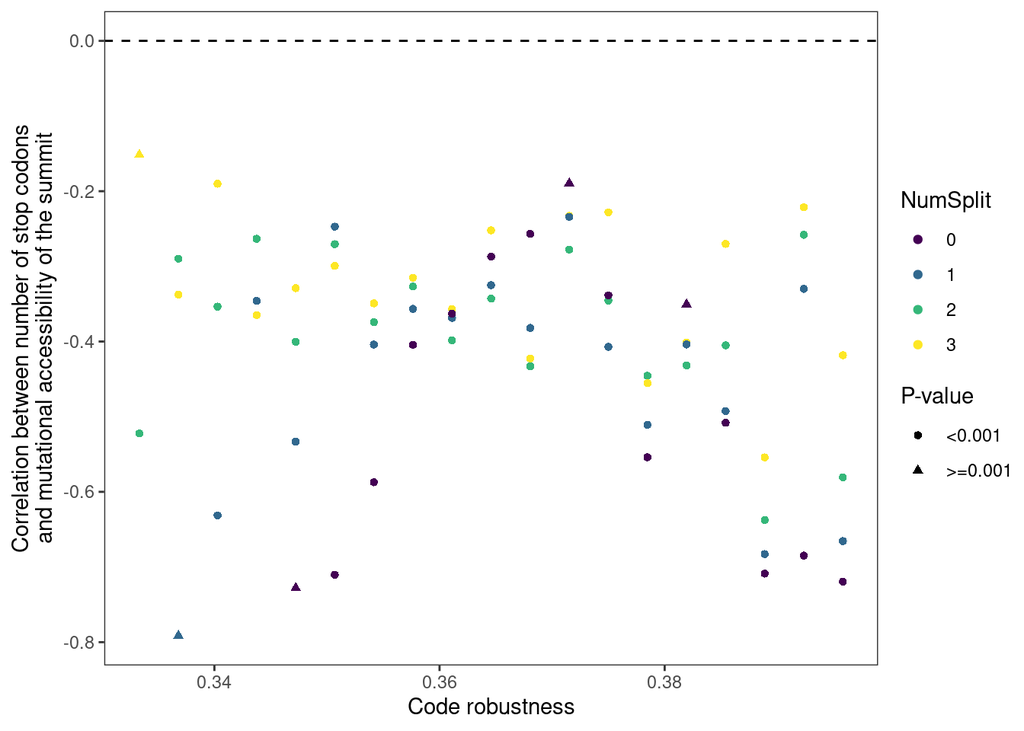

```r
data = data.frame(Robustness = robs2,
                  Correlation = corrs,
                  Pvalue = pvals,
                  NumSplit = numSplit)

data$pval_cat = ifelse(data$Pvalue>=0.05, ">=0.05",
                       ifelse(data$Pvalue>=0.01, ">=0.01",
                              ifelse(data$Pvalue>=0.001, ">=0.001", "<0.001")))

data$NumSplit = as.factor(data$NumSplit)
data = data[!is.na(data$Correlation),]
ggplot(data, aes(x=Robustness, y=Correlation, color=NumSplit, shape=pval_cat)) +
  geom_point() + theme_test() +
  labs(y="Correlation between number of stop codons\nand mutational accessibility of the summit", x="Code robustness", main="ParE3") +
  scale_color_viridis_d() + geom_hline(yintercept=0, linetype="dashed") +
  scale_shape_discrete(name="P-value")
```

# Epistasis

## No epistasis

#### Correlation with code robustness

```r
(corTest = cor.test(results$NoEpi, results$Robustness))
```

```
##
##  Pearson's product-moment correlation
##
## data:  results$NoEpi and results$Robustness
## t = 73.821, df = 194478, p-value < 2.2e-16
## alternative hypothesis: true correlation is not equal to 0
## 95 percent confidence interval:
##  0.1607727 0.1694192
## sample estimates:
##       cor
## 0.1650991
```

#### Number of split codon blocks

Correlation:

```r
(corTest = cor.test(results$numSplitBlocks, results$NoEpi))
```

```
##
##  Pearson's product-moment correlation
##
## data:  results$numSplitBlocks and results$NoEpi
## t = -431.21, df = 194478, p-value < 2.2e-16
## alternative hypothesis: true correlation is not equal to 0
## 95 percent confidence interval:
##  -0.7013914 -0.6968472
## sample estimates:
##        cor
## -0.6991263
```

Hold robustness constant, is there still correlation between number of split codon blocks and no epistasis?

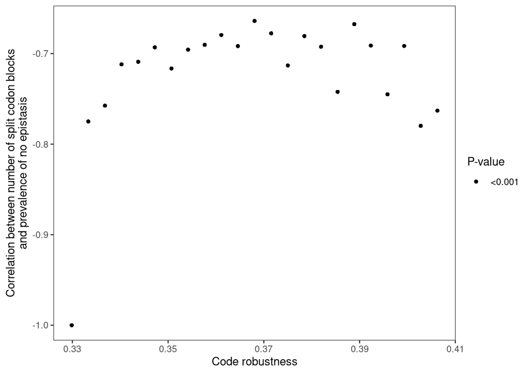

```r
corrs = c()
pvals = c()
robs = unique(results$Robustness)
for (rob in robs) {
  tmp = results[results$Robustness==rob,]
  test = cor.test(tmp$numSplitBlocks, tmp$NoEpi)
  corrs = c(corrs, test$estimate)
  pvals = c(pvals, test$p.value)
}
data = data.frame(Robustness = robs,
                  Correlation = corrs,
                  Pvalue = pvals)

data$pval_cat = ifelse(data$Pvalue>=0.05, ">=0.05",
                       ifelse(data$Pvalue>=0.01, ">=0.01",
                              ifelse(data$Pvalue>=0.001, ">=0.001", "<0.001")))

ggplot(data, aes(x=Robustness, y=Correlation, shape=pval_cat)) +
  geom_point() + theme_test() +
  labs(y="Correlation between number of split codon blocks\nand prevalence of no epistasis", x="Code robustness") +
  scale_shape_discrete(name="P-value")
```

#### Number of stop codons

```r
cor.test(results$numStop, results$NoEpi)
```

```
##
##  Pearson's product-moment correlation
##
## data:  results$numStop and results$NoEpi
## t = 486.5, df = 194478, p-value < 2.2e-16
## alternative hypothesis: true correlation is not equal to 0
## 95 percent confidence interval:
##  0.7388981 0.7429075
## sample estimates:
##       cor
## 0.7409094
```

```r
for (numSplit in unique(results$numSplitBlocks)) {
  print(numSplit)
  tmp = results[results$numSplitBlocks==numSplit,]
  print(cor.test(tmp$numStop, tmp$NoEpi))
}
```

```
## [1] 3
##
##  Pearson's product-moment correlation
##
## data:  tmp$numStop and tmp$NoEpi
## t = 384.04, df = 70868, p-value < 2.2e-16
## alternative hypothesis: true correlation is not equal to 0
## 95 percent confidence interval:
##  0.8194527 0.8242319
## sample estimates:
##       cor
## 0.8218568
##
## [1] 2
##
##  Pearson's product-moment correlation
##
## data:  tmp$numStop and tmp$NoEpi
## t = 342.87, df = 64093, p-value < 2.2e-16
## alternative hypothesis: true correlation is not equal to 0
## 95 percent confidence interval:
##  0.8017208 0.8071840
## sample estimates:
##       cor
## 0.8044694
##
## [1] 1
##
##  Pearson's product-moment correlation
##
## data:  tmp$numStop and tmp$NoEpi
## t = 207.09, df = 25965, p-value < 2.2e-16
## alternative hypothesis: true correlation is not equal to 0
## 95 percent confidence interval:
##  0.7845929 0.7937677
## sample estimates:
##       cor
## 0.7892243
##
## [1] 4
```

```
##
##  Pearson's product-moment correlation
##
## data:  tmp$numStop and tmp$NoEpi
## t = NA, df = 29581, p-value = NA
## alternative hypothesis: true correlation is not equal to 0
## 95 percent confidence interval:
##  NA NA
## sample estimates:
## cor
##  NA
##
## [1] 0
##
##  Pearson's product-moment correlation
##
## data:  tmp$numStop and tmp$NoEpi
## t = 76.594, df = 3963, p-value < 2.2e-16
## alternative hypothesis: true correlation is not equal to 0
## 95 percent confidence interval:
##  0.7596906 0.7848047
## sample estimates:
##       cor
## 0.7725496
```

Hold robustness constant, is there still correlation?

```r
corrs = c()
pvals = c()
numSplit = c()
robs = unique(results$Robustness)
robs2 = c()
for (rob in robs) {
  tmp = results[results$Robustness==rob,]
  numsplits = unique(tmp$numSplitBlocks)
  for (ns in numsplits) {
    tmp_tmp = tmp[tmp$numSplitBlocks==ns,]
    test = cor.test(tmp_tmp$numStop, tmp_tmp$NoEpi)
    corrs = c(corrs, test$estimate)
    pvals = c(pvals, test$p.value)
    numSplit = c(numSplit, ns)
    robs2 = c(robs2, rob)
  }
}
```

[output not shown]

[output cut: 18 more lines]

[output not shown]

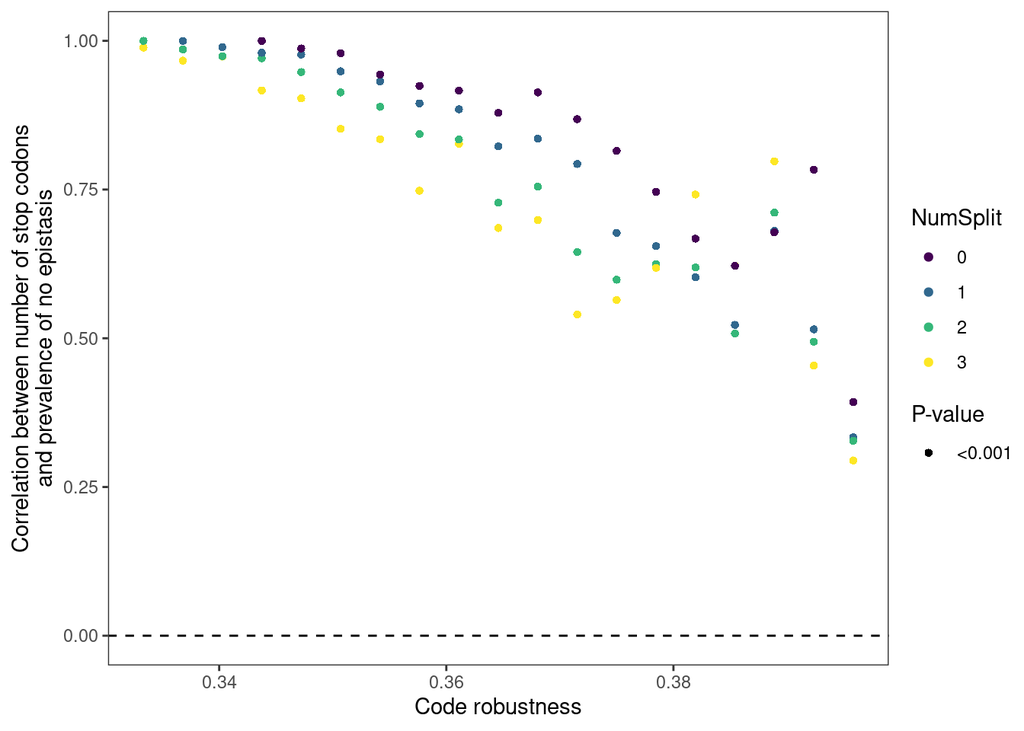

```r
data = data.frame(Robustness = robs2,
                  Correlation = corrs,
                  Pvalue = pvals,
                  NumSplit = numSplit)

data$pval_cat = ifelse(data$Pvalue>=0.05, ">=0.05",
                       ifelse(data$Pvalue>=0.01, ">=0.01",
                              ifelse(data$Pvalue>=0.001, ">=0.001", "<0.001")))

data$NumSplit = as.factor(data$NumSplit)
data = data[!is.na(data$Correlation),]
 ggplot(data, aes(x=Robustness, y=Correlation, color=NumSplit, shape=pval_cat)) +
  geom_point() + theme_test() +
  labs(y="Correlation between number of stop codons\nand prevalence of no epistasis", x="Code robustness", main="ParE3") +
  scale_color_viridis_d() + geom_hline(yintercept=0, linetype="dashed") +
  scale_shape_discrete(name="P-value")
```

## Magnitude epistasis

#### Correlation with code robustness

```r
(corTest = cor.test(results$MagEpi, results$Robustness))
```

```
##
##  Pearson's product-moment correlation
##
## data:  results$MagEpi and results$Robustness
## t = -58.78, df = 194478, p-value < 2.2e-16
## alternative hypothesis: true correlation is not equal to 0
## 95 percent confidence interval:
##  -0.1364842 -0.1277506
## sample estimates:
##      cor
## -0.13212
```

#### Number of split codon blocks

Correlation:

```r
(corTest = cor.test(results$numSplitBlocks, results$MagEpi))
```

```
##
##  Pearson's product-moment correlation
##
## data:  results$numSplitBlocks and results$MagEpi
## t = 218.23, df = 194478, p-value < 2.2e-16
## alternative hypothesis: true correlation is not equal to 0
## 95 percent confidence interval:
##  0.4399443 0.4470846
## sample estimates:
##       cor
## 0.4435215
```

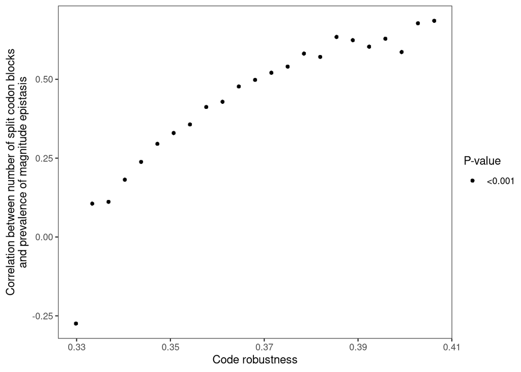

```r
corrs = c()
pvals = c()
robs = unique(results$Robustness)
for (rob in robs) {
  tmp = results[results$Robustness==rob,]
  test = cor.test(tmp$numSplitBlocks, tmp$MagEpi)
  corrs = c(corrs, test$estimate)
  pvals = c(pvals, test$p.value)
}
data = data.frame(Robustness = robs,
                  Correlation = corrs,
                  Pvalue = pvals)

data$pval_cat = ifelse(data$Pvalue>=0.05, ">=0.05",
                       ifelse(data$Pvalue>=0.01, ">=0.01",
                              ifelse(data$Pvalue>=0.001, ">=0.001", "<0.001")))

ggplot(data, aes(x=Robustness, y=Correlation, shape=pval_cat)) +
  geom_point() + theme_test() +
  labs(y="Correlation between number of split codon blocks\nand prevalence of magnitude epistasis", x="Code robustness") +
  scale_shape_discrete(name="P-value")
```

#### Number of stop codons

```r
cor.test(results$numStop, results$MagEpi)
```

```
##
##  Pearson's product-moment correlation
##
## data:  results$numStop and results$MagEpi
## t = -23.349, df = 194478, p-value < 2.2e-16
## alternative hypothesis: true correlation is not equal to 0
## 95 percent confidence interval:
##  -0.05730197 -0.04843806
## sample estimates:
##         cor
## -0.05287106
```

```r
for (numSplit in unique(results$numSplitBlocks)) {
  print(numSplit)
  tmp = results[results$numSplitBlocks==numSplit,]
  print(cor.test(tmp$numStop, tmp$MagEpi))
}
```

```
## [1] 3
##
##  Pearson's product-moment correlation
##
## data:  tmp$numStop and tmp$MagEpi
## t = 24.172, df = 70868, p-value < 2.2e-16
## alternative hypothesis: true correlation is not equal to 0
## 95 percent confidence interval:
##  0.08312009 0.09772445
## sample estimates:
##        cor
## 0.09042713
##
## [1] 2
##
##  Pearson's product-moment correlation
##
## data:  tmp$numStop and tmp$MagEpi
## t = 22.352, df = 64093, p-value < 2.2e-16
## alternative hypothesis: true correlation is not equal to 0
## 95 percent confidence interval:
##  0.08026220 0.09562589
## sample estimates:
##        cor
## 0.08794928
##
## [1] 1
##
##  Pearson's product-moment correlation
##
## data:  tmp$numStop and tmp$MagEpi
## t = 11.459, df = 25965, p-value < 2.2e-16
## alternative hypothesis: true correlation is not equal to 0
## 95 percent confidence interval:
##  0.05882213 0.08302575
## sample estimates:
##        cor
## 0.07093438
##
## [1] 4
```

```
##
##  Pearson's product-moment correlation
##
## data:  tmp$numStop and tmp$MagEpi
## t = NA, df = 29581, p-value = NA
## alternative hypothesis: true correlation is not equal to 0
## 95 percent confidence interval:
##  NA NA
## sample estimates:
## cor
##  NA
##
## [1] 0
##
##  Pearson's product-moment correlation
##
## data:  tmp$numStop and tmp$MagEpi
## t = 3.8378, df = 3963, p-value = 0.0001261
## alternative hypothesis: true correlation is not equal to 0
## 95 percent confidence interval:
##  0.02977973 0.09180533
## sample estimates:
##        cor
## 0.06085127
```

Hold robustness constant, is there still correlation?

```r
corrs = c()
pvals = c()
numSplit = c()
robs = unique(results$Robustness)
robs2 = c()
for (rob in robs) {
  tmp = results[results$Robustness==rob,]
  numsplits = unique(tmp$numSplitBlocks)
  for (ns in numsplits) {
    tmp_tmp = tmp[tmp$numSplitBlocks==ns,]
    test = cor.test(tmp_tmp$numStop, tmp_tmp$MagEpi)
    corrs = c(corrs, test$estimate)
    pvals = c(pvals, test$p.value)
    numSplit = c(numSplit, ns)
    robs2 = c(robs2, rob)
  }
}
```

[output not shown]

[output cut: 18 more lines]

[output not shown]

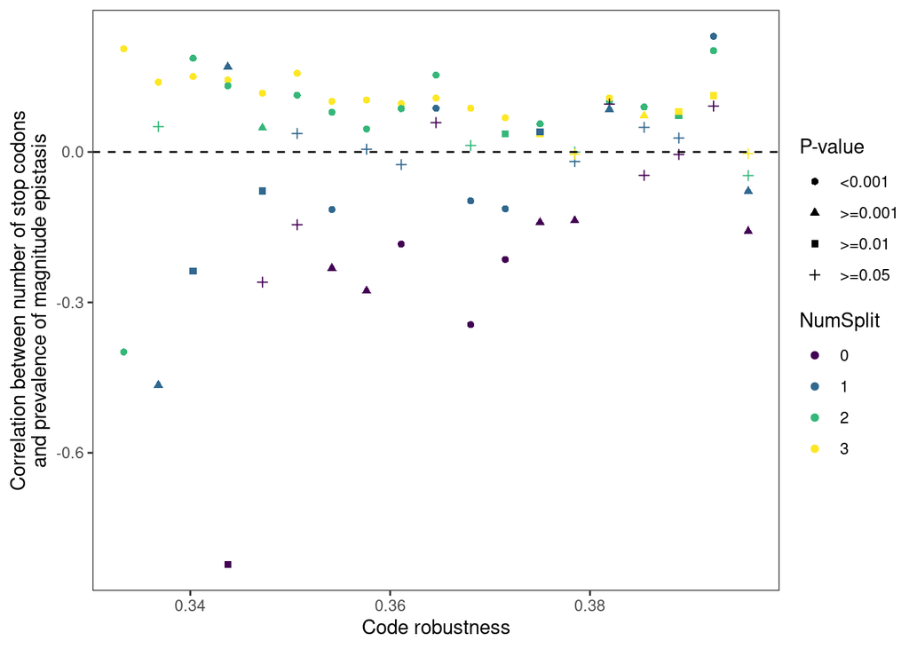

```r
data = data.frame(Robustness = robs2,
                  Correlation = corrs,
                  Pvalue = pvals,
                  NumSplit = numSplit)

data$pval_cat = ifelse(data$Pvalue>=0.05, ">=0.05",
                       ifelse(data$Pvalue>=0.01, ">=0.01",
                              ifelse(data$Pvalue>=0.001, ">=0.001", "<0.001")))

data$NumSplit = as.factor(data$NumSplit)
data = data[!is.na(data$Correlation),]
ggplot(data, aes(x=Robustness, y=Correlation, color=NumSplit, shape=pval_cat)) +
  geom_point() + theme_test() +
  labs(y="Correlation between number of stop codons\nand prevalence of magnitude epistasis", x="Code robustness", main="ParE3") +
  scale_color_viridis_d() + geom_hline(yintercept=0, linetype="dashed") +
  scale_shape_discrete(name="P-value")
```

## Simple-sign epistasis

#### Correlation with code robustness

```r
(corTest = cor.test(results$SsEpi, results$Robustness))
```

```
##
##  Pearson's product-moment correlation
##
## data:  results$SsEpi and results$Robustness
## t = -28.767, df = 194478, p-value < 2.2e-16
## alternative hypothesis: true correlation is not equal to 0
## 95 percent confidence interval:
##  -0.06951725 -0.06066616
## sample estimates:
##         cor
## -0.06509298
```

#### Number of split codon blocks

Correlation:

```r
(corTest = cor.test(results$numSplitBlocks, results$SsEpi))
```

```
##
##  Pearson's product-moment correlation
##
## data:  results$numSplitBlocks and results$SsEpi
## t = 244.86, df = 194478, p-value < 2.2e-16
## alternative hypothesis: true correlation is not equal to 0
## 95 percent confidence interval:
##  0.4820337 0.4888278
## sample estimates:
##       cor
## 0.4854381
```

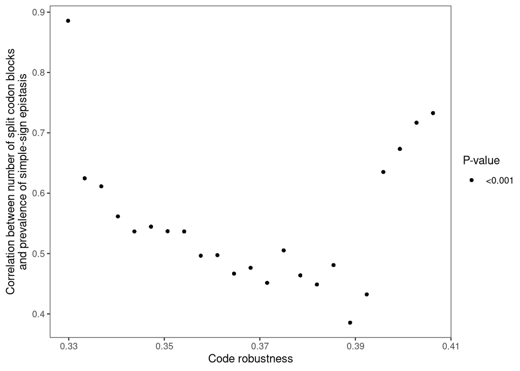

```r
corrs = c()
pvals = c()
robs = unique(results$Robustness)
for (rob in robs) {
  tmp = results[results$Robustness==rob,]
  test = cor.test(tmp$numSplitBlocks, tmp$SsEpi)
  corrs = c(corrs, test$estimate)
  pvals = c(pvals, test$p.value)
}
data = data.frame(Robustness = robs,
                  Correlation = corrs,
                  Pvalue = pvals)

data$pval_cat = ifelse(data$Pvalue>=0.05, ">=0.05",
                       ifelse(data$Pvalue>=0.01, ">=0.01",
                              ifelse(data$Pvalue>=0.001, ">=0.001", "<0.001")))

ggplot(data, aes(x=Robustness, y=Correlation, shape=pval_cat)) +
  geom_point() + theme_test() +
  labs(y="Correlation between number of split codon blocks\nand prevalence of simple-sign epistasis", x="Code robustness") +
  scale_shape_discrete(name="P-value")
```